# ME314 Managing and Visualizing Data

### 1. Normalizing data

This question uses this table:

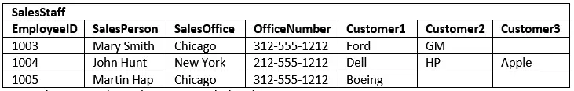

from the lecture notes. For each answer, please explain as fully as possible, and feel free to use tables or diagrams if you prefer.

1. Why does this table violate the first normal form, and what would be required to make it 1NF?

**This table violates the first normal form due to the wide format of Customer1, Customer2 and Customer3, indicating repeating group of element.**

**To make it 1NF, create 3 tables:** **- Office database that consist of Office ID, Location and Office Number** **- Customer database that contains Office ID, Customer name and Employee ID** **- Employee database with Employee ID, employee’s name and Office ID**

2. What additional steps would be needed to make the table 2NF, and why?

**After converting the table into 1NF, it still violates the format as there are repeated entries of “Chicago” under “SalesOffice” category. To make it 2NF, construct 2 tables out of the 1NF table, with:** **- First table consist of “EmployeeID”, “SalesOffice” and “Office Number”** **- Second table consist of “EmployeeID” and “Customer” column.**

3. Why might we not want to normalize data to the fullest extent possible?

**Overnormalization implies an increase in number of joins required in a query between related table. The biggest problem with normalization is that we will end up with multiple tables storing information about a single item. The use of multiple joins to assess information makes the process intensive and slow to take place.**

4. In the table below, which of the three normalization rules does this violate, if any, and why?

| countryID | countryName | EUmember | EUjoindate |
| --- | --- | --- | --- |
| 00001 | France | `true` | 1958-01-01 |
| 00004 | Hungary | `true` | 2004-05-01 |
| 00003 | Serbia | `false` | `NULL` |
| 00004 | Finland | `true` | 1995-01-01 |
| 00005 | Russia | `false` | `NULL` |
| 00006 | Ireland, UK | `true` | 1973-01-01 |

Are there any other problems with the table, besides normalization?

**The table violates the first normalization rule (1NF) because the “countryName” column has multiple values separated by a comma for the row with “Ireland, UK”.**

**Regarding other problems, the “countryID” column has duplicate values (e.g., “00004” appears twice). Additionally, the “EUjoindate” column has null values for the rows with “Serbia” and “Russia”.**

5. What would it take to full (1NF-3NF) normalize this dataset? **To fully normalize the data to 3NF:** **1. 1NF** **- Create a separate column for each data in the “countryName” column.** **- Create a separate column for each data in the “EUjoindate” column.**

   ```
    |  countryID  |  countryName1 |  countryName2 |   EUmember   |  EUjoindateYear  |  EUjoindateMonth | EUjoindateDay|
    | -----------:|:--------------|:--------------|:-------------|:-----------------|:-----------------|:-------------|
    | 00001       | France        |               |  `true`      |  1958            |  01              | 01           |
    | 00004       | Hungary       |               |  `true`      |  2004            |  05              | 01           |
    | 00003       | Serbia        |               |  `false`     |                  |                  |              |
    | 00004       | Finland       |               |  `true`      |  1995            |  01              | 01           |
    | 00005       | Russia        |               |  `false`     |                  |                  |              |
    | 00006       | Ireland       |  UK           |  `true`      |  1973            |  01              | 01           |
   ```

**2. 2NF** **- Create a separate table for the “countryID” and “EUmember” columns, with “countryID” as the primary key.** **- Create a separate table for the “countryID”, “EUjoindateYear”, “EUjoindateMonth”, and “EUjoindateDay” columns, with “countryID” as the primary key.**

[output not shown]

**3. 3NF** **There are no transitive dependence in the dataset after 2NF. No transformation needed. The data is already in 3NF.**

Write out these tables, and describe why this meets each of the normal forms. This is a database of movies watched on NetBricks, a streaming movie service.

| Name | Address | Movies Rented | Salutation | Category |
| --- | --- | --- | --- | --- |
| Bob Smith | 1 Houghton Street | *Star Wars*, *Inception* | Dr. | Scifi, Scifi |
| Pry Ministair | 10 Downing St | *Brexit the Movie* | Lady | Tragedy |
| Joe Bloggs | 8 Myhatt St. | *Fast and Furious 6*, *Fast and Furious 7* | Mr. | Action, Action |

**This table does not meet the first normal form (1NF) since the Movies Rented column has multiple values in a single cell. To achieve 1NF, we would need to split the Movies Rented column into multiple rows.**

**To achieve 2NF, we could create a separate table for the Movies Rented column and use a foreign key to link it to the original table. This would ensure that we do not have any repeating groups in our table.**

**To achieve 3NF, we could further normalize the table by creating separate tables for Salutation and Category, each with their own primary key. We could then use a foreign key to link these tables to our original table.**

**In the end, the normalized tables might look something like this:**

```
| CustomerID  | First Name  | Last Name |     | AddressID  | Street            |     | SalutationID  | Salutation  |
|------------:|:------------|:----------|     | ----------:|:------------------|     |--------------:|:------------|
| 001         | Bob         | Smith     |     | 001        | 1 Houghton Street |     | 001           | Dr.         |
| 002         | Pry         | Ministair |     | 002        | 10 Downing St.    |     | 002           | Lady        |
| 003         | Joe         | Bloggs    |     | 003        | 8 Myhatt St.      |     | 003           | Mr.         |


| MovieID | Movie Title         |      | CategoryID | Category |
|--------:|:--------------------|      |-----------:|:---------|
| 001     | Star Wars           |      | 001        | Scifi    |
| 002     | Inception           |      | 002        | Tragedy  |
|  003     | Brexit the Movie   |      | 003        | Action   |
| 004     | Fast and Furious 6  |
| 005     | Fast and Furious 7  |

|RentalID | NameID | AddressID | MovieID | SalutationID | CategoryID  |
|--------:|:-------|:----------|:--------|:-------------|:------------|
| 001     | 001    | 001       | 001     | 001          | 001         |
| 002     | 001    | 001       | 002     | 001          | 001         |
| 003     | 002    | 002       | 003     | 002          | 002         |
| 004     | 003    | 003       | 004     | 003          | 003         |
| 005     | 003    | 003       | 005     | 003          | 003         |
```

### 2. Reshaping data

For this exercise, we will use the **nycflights13** R package, whose tables have been output in `.csv` form here. You may do the following in either R or Python. Note that this example is developed extensively in [*R for Data Science*](http://r4ds.had.co.nz/relational-data.html).

1. Create a subtable of the `flights` data, that departed before 05:53 on 2013-02-28. How many rows and columns does this subtable have?

```r
library("dplyr", quietly = TRUE)
library("lubridate", quietly = TRUE)
flights <- read.csv("nycflights13/flights.csv")

#Add a new colum dep_datetime by concatenating year, month, day, hour and minute column
flights$dep_datetime <- ymd_hm(sprintf("%s-%02d-%02d %02d:%02d",
                            flights$year,
                            flights$month,
                            flights$day,
                            flights$hour,
                            flights$minute))

#Subtable of flights data with departure time before 05:53 on 2013-02-28
flights_sub <- subset(flights, dep_datetime < ymd_hm("2013-02-28 05:53"))
head(flights_sub)
```

```
##   X year month day dep_time sched_dep_time dep_delay arr_time sched_arr_time
## 1 1 2013     1   1      517            515         2      830            819
## 2 2 2013     1   1      533            529         4      850            830
## 3 3 2013     1   1      542            540         2      923            850
## 4 4 2013     1   1      544            545        -1     1004           1022
## 5 5 2013     1   1      554            600        -6      812            837
## 6 6 2013     1   1      554            558        -4      740            728
##   arr_delay carrier flight tailnum origin dest air_time distance hour minute
## 1        11      UA   1545  N14228    EWR  IAH      227     1400    5     15
## 2        20      UA   1714  N24211    LGA  IAH      227     1416    5     29
## 3        33      AA   1141  N619AA    JFK  MIA      160     1089    5     40
## 4       -18      B6    725  N804JB    JFK  BQN      183     1576    5     45
## 5       -25      DL    461  N668DN    LGA  ATL      116      762    6      0
## 6        12      UA   1696  N39463    EWR  ORD      150      719    5     58
##             time_hour        dep_datetime
## 1 2013-01-01 05:00:00 2013-01-01 05:15:00
## 2 2013-01-01 05:00:00 2013-01-01 05:29:00
## 3 2013-01-01 05:00:00 2013-01-01 05:40:00
## 4 2013-01-01 05:00:00 2013-01-01 05:45:00
## 5 2013-01-01 06:00:00 2013-01-01 06:00:00
## 6 2013-01-01 05:00:00 2013-01-01 05:58:00
```

```r
cat(paste("Number of rows: ", nrow(flights_sub), '\n'))
```

```
## Number of rows:  50996
```

```r
cat(paste("Number of columns: ", ncol(flights_sub)))
```

```
## Number of columns:  21
```

```r
#Alternative Methods using dplyr Packages
#flights <- flights %>% dplyr :: mutate(dep_datetime_alt = paste(paste(year, month, day, sep = "="),paste(hour, minute, "0", sep = ";"),sep = " "))
#head(flights)
#flights_sub <- subset(flights, dep_datetime < ymd_hm("2013-02-28 05:53"))
```

2. Merge or join the subtable from a. `flights` data, to produce a result that includes:
- Departure time
- Carrier (two digit code, from `carrier`)
- Flight number
- Destination airport name (hint: you will need to get this from the `airports` table)

```r
#Load the airports table
airports <- read.csv("nycflights13/airports.csv")
head(airports)
```

```
##   X faa                           name      lat       lon  alt tz dst
## 1 1 04G              Lansdowne Airport 41.13047 -80.61958 1044 -5   A
## 2 2 06A  Moton Field Municipal Airport 32.46057 -85.68003  264 -6   A
## 3 3 06C            Schaumburg Regional 41.98934 -88.10124  801 -6   A
## 4 4 06N                Randall Airport 41.43191 -74.39156  523 -5   A
## 5 5 09J          Jekyll Island Airport 31.07447 -81.42778   11 -5   A
## 6 6 0A9 Elizabethton Municipal Airport 36.37122 -82.17342 1593 -5   A
##              tzone
## 1 America/New_York
## 2  America/Chicago
## 3  America/Chicago
## 4 America/New_York
## 5 America/New_York
## 6 America/New_York
```

```r
#Merging two tables
head(flights_sub[,-1])
```

```
##   year month day dep_time sched_dep_time dep_delay arr_time sched_arr_time
## 1 2013     1   1      517            515         2      830            819
## 2 2013     1   1      533            529         4      850            830
## 3 2013     1   1      542            540         2      923            850
## 4 2013     1   1      544            545        -1     1004           1022
## 5 2013     1   1      554            600        -6      812            837
## 6 2013     1   1      554            558        -4      740            728
##   arr_delay carrier flight tailnum origin dest air_time distance hour minute
## 1        11      UA   1545  N14228    EWR  IAH      227     1400    5     15
## 2        20      UA   1714  N24211    LGA  IAH      227     1416    5     29
## 3        33      AA   1141  N619AA    JFK  MIA      160     1089    5     40
## 4       -18      B6    725  N804JB    JFK  BQN      183     1576    5     45
## 5       -25      DL    461  N668DN    LGA  ATL      116      762    6      0
## 6        12      UA   1696  N39463    EWR  ORD      150      719    5     58
##             time_hour        dep_datetime
## 1 2013-01-01 05:00:00 2013-01-01 05:15:00
## 2 2013-01-01 05:00:00 2013-01-01 05:29:00
## 3 2013-01-01 05:00:00 2013-01-01 05:40:00
## 4 2013-01-01 05:00:00 2013-01-01 05:45:00
## 5 2013-01-01 06:00:00 2013-01-01 06:00:00
## 6 2013-01-01 05:00:00 2013-01-01 05:58:00
```

```r
tmp <- merge(flights_sub[,-1],airports[,-1], by.x = "dest", by.y = "faa", all.x = TRUE)

#Demonstration
nodup <- flights_sub[!duplicated(flights_sub$dest),]
dtmp <- merge(nodup, airports, by.x = "dest", by.y = "faa", all.x = TRUE)
dtmp %>% dplyr :: select(dest,name) %>% head()
```

```
##   dest                            name
## 1  ALB                     Albany Intl
## 2  ATL Hartsfield Jackson Atlanta Intl
## 3  AUS           Austin Bergstrom Intl
## 4  AVL      Asheville Regional Airport
## 5  BDL                    Bradley Intl
## 6  BHM                 Birmingham Intl
```

```r
#Checking if Merging is Successful
length(tmp$dest)
```

```
## [1] 50996
```

```r
length(flights_sub$dest)
```

```
## [1] 50996
```

```r
length(airports$faa)
```

```
## [1] 1458
```

```r
names(tmp)
```

```
##  [1] "dest"           "year"           "month"          "day"
##  [5] "dep_time"       "sched_dep_time" "dep_delay"      "arr_time"
##  [9] "sched_arr_time" "arr_delay"      "carrier"        "flight"
## [13] "tailnum"        "origin"         "air_time"       "distance"
## [17] "hour"           "minute"         "time_hour"      "dep_datetime"
## [21] "name"           "lat"            "lon"            "alt"
## [25] "tz"             "dst"            "tzone"
```

```r
answer2 <- select(tmp,c("dep_time", "carrier", "flight", "name"))

#Alternative Way
#answer2 <- tmp %>% dplyr :: select("dep_time", "carrier", "flight", "name")
print(answer2)
```

```
##       dep_time carrier flight                                 name
## 1         1755      EV   4271                          Albany Intl
## 2         1733      EV   4271                          Albany Intl
## 3         1958      EV   4309                          Albany Intl
## 4         1712      EV   4271                          Albany Intl
## 5         1708      EV   4093                          Albany Intl
## 6         1722      EV   4271                          Albany Intl
## 7         1956      EV   4309                          Albany Intl
## 8         1624      EV   4271                          Albany Intl
## 9         1614      EV   4093                          Albany Intl
## 10        1721      EV   4271                          Albany Intl
## 11        2053      EV   4309                          Albany Intl
## 12          NA      EV   4309                          Albany Intl
## 13         817      EV   4199                          Albany Intl
## 14        1617      EV   4271                          Albany Intl
```

[output cut: 24986 more lines]

3. **(optional)** For every airline that had flights in the `flights` data compute the average age of the planes it flew from the entire dataset. Age here will be defined as 2013 minus the `year` variable from the `planes` data. Hint: This involves a join operation on `tailnum`, but also a grouped mean to compute the age (and subtracting 2013, which you can do before or after the computation of the mean).

```r
## your code
planes <- read.csv("nycflights13/planes.csv")

tmp1 <- flights %>%
  filter(!duplicated(tailnum)) %>%
  select(c("tailnum", "carrier") ) %>%
  left_join(planes, by = "tailnum")

airlines <- read.csv("nycflights13/airlines.csv")

tmp1 %>% group_by(carrier) %>%
  summarize(mean_age = mean(2013 - year, na.rm = TRUE)) %>%
  left_join(airlines, by = "carrier") %>%
  select(c("name", "mean_age"))
```

```
## # A tibble: 16 × 2
##    name                        mean_age
##    <chr>                          <dbl>
##  1 Endeavor Air Inc.               8.29
##  2 American Airlines Inc.         25.4
##  3 Alaska Airlines Inc.            5.16
##  4 JetBlue Airways                 6.50
##  5 Delta Air Lines Inc.           17.8
##  6 ExpressJet Airlines Inc.       10.7
##  7 Frontier Airlines Inc.          5
##  8 AirTran Airways Corporation    10.8
##  9 Hawaiian Airlines Inc.          1.23
## 10 Envoy Air                      35.5
## 11 SkyWest Airlines Inc.           7.14
## 12 United Air Lines Inc.          13.1
## 13 US Airways Inc.                11.0
## 14 Virgin America                  4.29
## 15 Southwest Airlines Co.         11.0
## 16 Mesa Airlines Inc.              9.44
```

### 3. Working with SQL

1. Create a relational dataset in SQLite using the `.csv` data found here. Name each table so that it matches the base filenames of the input data. You can use DB Browser for this, but describe how you did it, but the answer will use the R package [RSQLite](https://cran.r-project.org/web/packages/RSQLite/RSQLite.pdf).

```r
library("RSQLite")
mydb <- dbConnect(SQLite(), "")

dbWriteTable(mydb, "flights", read.csv("nycflights13/flights.csv"))
dbWriteTable(mydb, "airlines", read.csv("nycflights13/airlines.csv"))
dbWriteTable(mydb, "airports", read.csv("nycflights13/airports.csv"))
dbWriteTable(mydb, "weather", read.csv("nycflights13/weather.csv"))
dbWriteTable(mydb, "planes", read.csv("nycflights13/planes.csv"))
```

2. Replicate 2B above using an SQL query, including both the command and the output.

```r
# dep_datetime is stored as the epoch second
# calculate the epoch sec with as.integer(lubridate::ymd_hm())
answer3b <- dbGetQuery(mydb, "SELECT dep_time, carrier, flight, name FROM
            flights AS fl
            LEFT JOIN airports AS ap ON
            fl.dest = ap.faa
            WHERE fl.year = 2013 AND month = 2 AND day = 28 AND dep_time < 553")
print(answer3b)
```

```
##    dep_time carrier flight                            name
## 1       457      US   1117          Charlotte Douglas Intl
## 2       458      UA    697    George Bush Intercontinental
## 3       522      UA   1714    George Bush Intercontinental
## 4       539      AA   1141                      Miami Intl
## 5       540      B6    725                            <NA>
## 6       549      EV   4911          Detroit Metro Wayne Co
## 7       551      AA    301              Chicago Ohare Intl
## 8       551      MQ   4650 Hartsfield Jackson Atlanta Intl
## 9       552      AA    707          Dallas Fort Worth Intl
## 10      552      B6    371  Fort Lauderdale Hollywood Intl
```

3. **(optional)** Replicate 2c above using an SQL query, including both the command and the output.

```r
tmp2 <- dbGetQuery(mydb, "SELECT flights.carrier,
                  2013 - AVG(planes.year) FROM
                  (SELECT DISTINCT tailnum, carrier FROM flights) AS flights
                  LEFT JOIN planes ON flights.tailnum = planes.tailnum
                  GROUP BY flights.carrier")
tmp2
```

```
##    carrier 2013 - AVG(planes.year)
## 1       9E                8.287129
## 2       AA               25.402439
## 3       AS                5.156627
## 4       B6                6.497326
## 5       DL               17.671593
## 6       EV               10.558442
## 7       F9                5.000000
## 8       FL               10.794643
## 9       HA                1.230769
## 10      MQ               35.500000
## 11      OO                7.142857
## 12      UA               13.050934
## 13      US               10.996283
## 14      VX                4.288462
## 15      WN               11.005272
## 16      YV                9.438596
```

```r
tmp3 <- dbGetQuery(mydb, "SELECT flights.carrier, flights.tailnum,
                  2013 - planes.year FROM planes
                  LEFT JOIN (SELECT DISTINCT tailnum, carrier FROM flights) as flights
                  ON flights.tailnum = planes.tailnum
                  ")
tmp3
```

```
##      carrier tailnum 2013 - planes.year
## 1         EV  N10156                  9
## 2         US  N102UW                 15
## 3         US  N103US                 14
## 4         US  N104UW                 14
## 5         EV  N10575                 11
## 6         US  N105UW                 14
## 7         US  N107US                 14
## 8         US  N108UW                 14
## 9         US  N109UW                 14
## 10        US  N110UW                 14
## 11        EV  N11106                 11
## 12        EV  N11107                 11
## 13        EV  N11109                 11
## 14        EV  N11113                 11
```

[output cut: 3325 more lines]

[output not shown]